# Deliverable 1

```python
import pandas as pd
import numpy as np
from matplotlib import pyplot as plt
%matplotlib inline
import seaborn as sns
import warnings
warnings.filterwarnings('ignore')
```

```python
data = pd.read_csv("bank-full.csv")
data.head()
```

|  | age | job | marital | education | default | balance | housing | loan | contact | day | month | duration | campaign | pdays | previous | poutcome | Target |
| --- | --- | --- | --- | --- | --- | --- | --- | --- | --- | --- | --- | --- | --- | --- | --- | --- | --- |
| 0 | 58 | management | married | tertiary | no | 2143 | yes | no | unknown | 5 | may | 261 | 1 | -1 | 0 | unknown | no |
| 1 | 44 | technician | single | secondary | no | 29 | yes | no | unknown | 5 | may | 151 | 1 | -1 | 0 | unknown | no |
| 2 | 33 | entrepreneur | married | secondary | no | 2 | yes | yes | unknown | 5 | may | 76 | 1 | -1 | 0 | unknown | no |
| 3 | 47 | blue-collar | married | unknown | no | 1506 | yes | no | unknown | 5 | may | 92 | 1 | -1 | 0 | unknown | no |
| 4 | 33 | unknown | single | unknown | no | 1 | no | no | unknown | 5 | may | 198 | 1 | -1 | 0 | unknown | no |

```python
data.shape
```

```
(45211, 17)
```

## 1. Univariate Analysis

## 1a.

data types and description of the independent attributes which should include (name, meaning, range of values observed, central values (mean and median), standard deviation and quartiles, analysis of the body of distributions / tails, missing values, outliers.

```python
data.describe()
```

|  | age | balance | day | duration | campaign | pdays | previous |
| --- | --- | --- | --- | --- | --- | --- | --- |
| count | 45211.000000 | 45211.000000 | 45211.000000 | 45211.000000 | 45211.000000 | 45211.000000 | 45211.000000 |
| mean | 40.936210 | 1362.272058 | 15.806419 | 258.163080 | 2.763841 | 40.197828 | 0.580323 |
| std | 10.618762 | 3044.765829 | 8.322476 | 257.527812 | 3.098021 | 100.128746 | 2.303441 |
| min | 18.000000 | -8019.000000 | 1.000000 | 0.000000 | 1.000000 | -1.000000 | 0.000000 |
| 25% | 33.000000 | 72.000000 | 8.000000 | 103.000000 | 1.000000 | -1.000000 | 0.000000 |
| 50% | 39.000000 | 448.000000 | 16.000000 | 180.000000 | 2.000000 | -1.000000 | 0.000000 |
| 75% | 48.000000 | 1428.000000 | 21.000000 | 319.000000 | 3.000000 | -1.000000 | 0.000000 |
| max | 95.000000 | 102127.000000 | 31.000000 | 4918.000000 | 63.000000 | 871.000000 | 275.000000 |

```python
data.nunique()
```

```
age            77
job            12
marital         3
education       4
default         2
balance      7168
housing         2
loan            2
contact         3
day            31
month          12
duration     1573
campaign       48
pdays         559
previous       41
poutcome        4
Target          2
dtype: int64
```

```python
data.isnull().sum()
```

```
age          0
job          0
marital      0
education    0
default      0
balance      0
housing      0
loan         0
contact      0
day          0
month        0
duration     0
campaign     0
pdays        0
previous     0
poutcome     0
Target       0
dtype: int64
```

### From here, we need to analyze the different columns differently...

Get the boxplot for age, balance and campaign

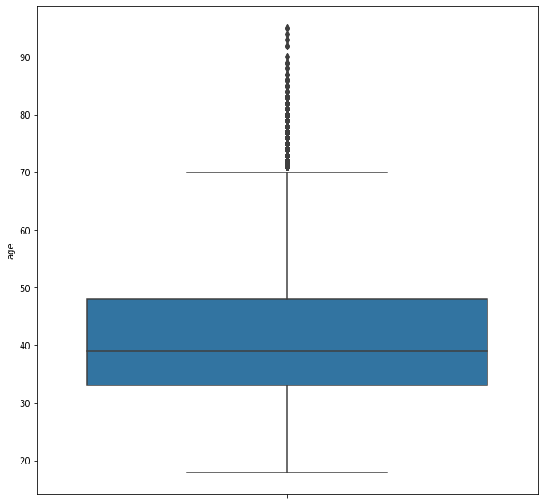

```python
plt.figure(figsize=(10,10))
sns.boxplot(y='age', data=data)
```

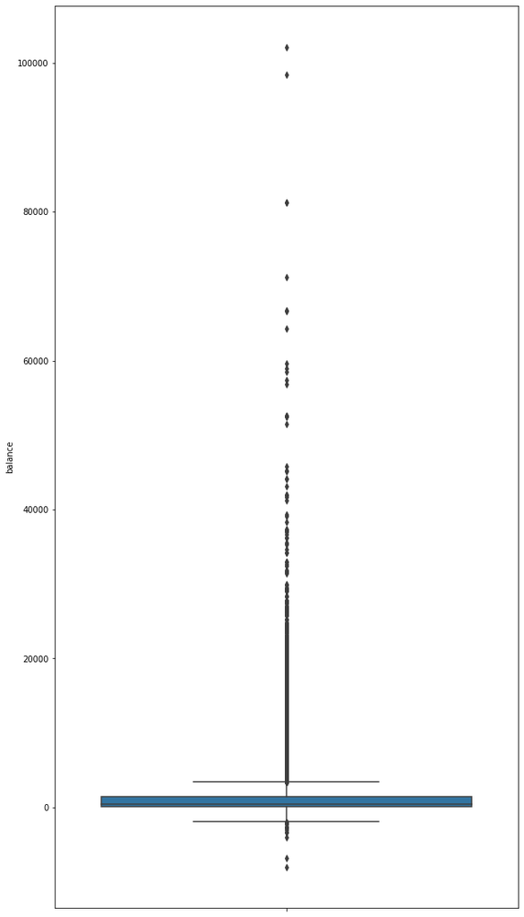

```python
plt.figure(figsize=(10,20))
sns.boxplot(y='balance', data=data)
```

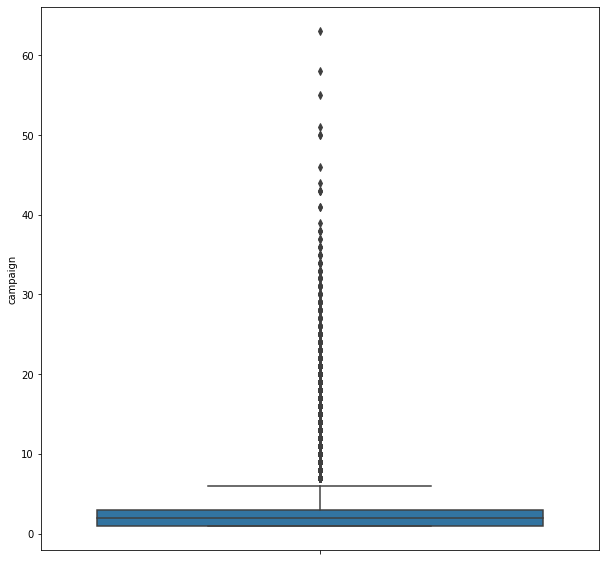

```python
plt.figure(figsize=(10,10))
sns.boxplot(y='campaign', data=data)
```

Then get the value counts for counts that have high recurring values either for numerical columns or categorical columns. I am particularly interested in finding the value counts for 'previous'and 'pdays' because there seem to be a significant amount of 0 and -1. I want to see how much of the data has no other unique value for those two fields.

```python
data.job.value_counts()
```

```
blue-collar      9732
management       9458
technician       7597
admin.           5171
services         4154
retired          2264
self-employed    1579
entrepreneur     1487
unemployed       1303
housemaid        1240
student           938
unknown           288
Name: job, dtype: int64
```

```python
data.marital.value_counts()
```

```
married     27214
single      12790
divorced     5207
Name: marital, dtype: int64
```

```python
data.education.value_counts()
```

```
secondary    23202
tertiary     13301
primary       6851
unknown       1857
Name: education, dtype: int64
```

```python
data.default.value_counts()
```

```
no     44396
yes      815
Name: default, dtype: int64
```

```python
data.housing.value_counts()
```

```
yes    25130
no     20081
Name: housing, dtype: int64
```

```python
data.loan.value_counts()
```

```
no     37967
yes     7244
Name: loan, dtype: int64
```

```python
data.contact.value_counts()
```

```
cellular     29285
unknown      13020
telephone     2906
Name: contact, dtype: int64
```

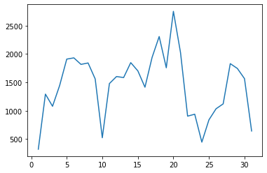

```python
#get the line plot of when the most contact happens throughout each month.
#It is more interesting to see it like this than as simple value_counts
sns.lineplot(data=data.day.value_counts())
```

```python
data.month.value_counts()
#looks like most of the contact happened May-Aug
```

```
may    13766
jul     6895
aug     6247
jun     5341
nov     3970
apr     2932
feb     2649
jan     1403
oct      738
sep      579
mar      477
dec      214
Name: month, dtype: int64
```

```python
data.campaign.value_counts()
#looks like most people wre contacted only once but there were some people who were contacted as much as 63 times.
#This could play a factor in whether that person subscribes if they are annoyed with how much they are being
#contacted
```

```
1     17544
2     12505
3      5521
4      3522
5      1764
6      1291
7       735
8       540
9       327
10      266
11      201
12      155
13      133
14       93
15       84
```

[output cut: 34 more lines]

```python
data.pdays.value_counts()
#we can see here most of the values of the dataset are -1
```

```
-1      36954
 182      167
 92       147
 183      126
 91       126
        ...
 749        1
 717        1
 589        1
 493        1
 32         1
Name: pdays, Length: 559, dtype: int64
```

```python
data.previous.value_counts()
#most the values here are 0
```

```
0      36954
1       2772
2       2106
3       1142
4        714
5        459
6        277
7        205
8        129
9         92
10        67
11        65
12        44
13        38
15        20
```

[output cut: 27 more lines]

```python
data.poutcome.value_counts()
```

```
unknown    36959
failure     4901
other       1840
success     1511
Name: poutcome, dtype: int64
```

```python
data.Target.value_counts()
```

```
no     39922
yes     5289
Name: Target, dtype: int64
```

### It does not make sense to get the value_counts of 'age', 'balance' and 'duration' as these seem to be continuous fields that do not have a high number of reoccurring values such as 'previous', 'campaign' and 'pdays'

## 1b and 1c.

Strategies to address the different data challenges such as data pollution, outlier’s treatment and missing values treatment.

- There don't seem to be any columns that have any nulls which is great.
- In all the boxplots above, there appear to be a significant number of outliers. To get rid of these many values will significantly and negatively impact the model because you always want more data. The number of outliers is pretty concerning for all three boxplots above.
- The poutcome column does have a lot of "unknown" values. We could a few things here. We could try to impute the 'unknowns' as 'other' or we could choose to ignore this column completely since 81.7% of the values are 'unknown' which is not helpful to us in using this as a feature. If the values of the unknowns were significantly smaller, I might opt to impute the mode to replace the unknowns but that would not be helpful here.
- The column balance has some extreme mins and max. Almost 8% of the balances are 0 or close to 0. This makes it very hard to plot this data in an effective way. I have filtered some of the data below to try to see a clearer view of it without the overwhelming number of 0 values. From balance >0 and balance <1500 , there are 60% of the values of the column meaning from 0-1499 (inclusive) we have 68% of the balance values.
- The 'previous' column has one significant outlier that I will remove with the value of 275. I will keep the othr less extreme outliers in the 50's range in order to have more data for my model.

I am doing to following just to get a better look at the graph of balances without so many extreme outliers

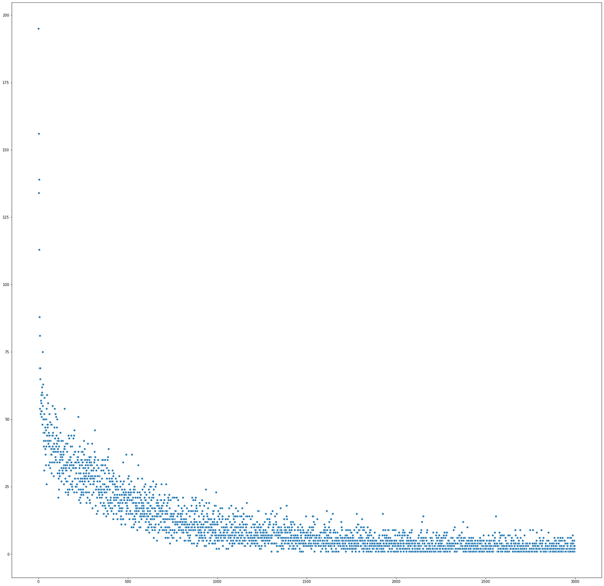

```python
df2 = data[(data.balance >0) & (data.balance <3000)]
plt.figure(figsize=(30,30))
sns.scatterplot(data=df2.balance.value_counts())
```

It looks like most people have between $0 and $1500 in their balance and then the scatterplot trails off continuing to decrease in counts for each higher balance value.

## 2. Multivariate Analysis

For the multivariate analysis, please note that I am removing the outliers and any records I do not want before doing my multivariate analysis.

```python
#get rid of extreme outliers, keep some others to save amount of data used
#since there are more 'unknown' values for poutcome than anything else, I will not use this column in the model
data2 = data[data.previous < 150]
data2 = data2[data2.duration < 4500]
data2 = data2.drop(['poutcome'], axis=1)
```

### 2a.

Bi-variate analysis between the predictor variables and target column. Visualize the analysis using boxplots and pair plots, histograms or density curves.

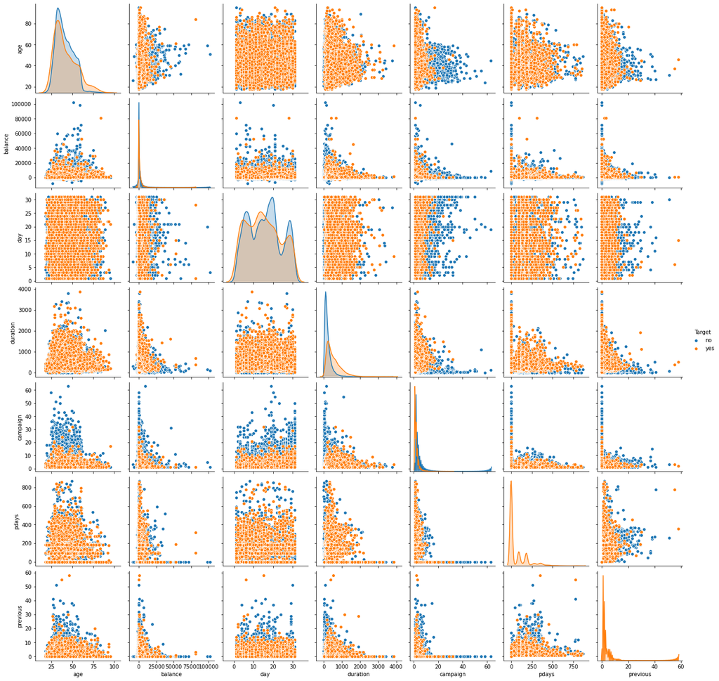

```python
sns.pairplot(data=data2, hue="Target")
```

# Deliverable 2

1. Ensure the attribute types are correct. If not, take appropriate actions.
2. Get the data model ready.
3. Transform the data i.e. scale / normalize if required
4. Create the training set and test set in ratio of 70:30

There are no clear and high correlations here so I will not need to encode these with anything except the dummy encoder. These features seem to be all independent.

```python
data_encoded = pd.get_dummies(data2 , columns=['job', 'marital', 'education', 'default', 'housing', 'loan', 'contact', 'month'])
data_encoded.transpose()
```

|  | 0 | 1 | 2 | 3 | 4 | 5 | 6 | 7 | 8 | 9 | ... | 45201 | 45202 | 45203 | 45204 | 45205 | 45206 | 45207 | 45208 | 45209 | 45210 |
| --- | --- | --- | --- | --- | --- | --- | --- | --- | --- | --- | --- | --- | --- | --- | --- | --- | --- | --- | --- | --- | --- |
| age | 58 | 44 | 33 | 47 | 33 | 35 | 28 | 42 | 58 | 43 | ... | 53 | 34 | 23 | 73 | 25 | 51 | 71 | 72 | 57 | 37 |
| balance | 2143 | 29 | 2 | 1506 | 1 | 231 | 447 | 2 | 121 | 593 | ... | 583 | 557 | 113 | 2850 | 505 | 825 | 1729 | 5715 | 668 | 2971 |
| day | 5 | 5 | 5 | 5 | 5 | 5 | 5 | 5 | 5 | 5 | ... | 17 | 17 | 17 | 17 | 17 | 17 | 17 | 17 | 17 | 17 |
| duration | 261 | 151 | 76 | 92 | 198 | 139 | 217 | 380 | 50 | 55 | ... | 226 | 224 | 266 | 300 | 386 | 977 | 456 | 1127 | 508 | 361 |
| campaign | 1 | 1 | 1 | 1 | 1 | 1 | 1 | 1 | 1 | 1 | ... | 1 | 1 | 1 | 1 | 2 | 3 | 2 | 5 | 4 | 2 |
| pdays | -1 | -1 | -1 | -1 | -1 | -1 | -1 | -1 | -1 | -1 | ... | 184 | -1 | -1 | 40 | -1 | -1 | -1 | 184 | -1 | 188 |
| previous | 0 | 0 | 0 | 0 | 0 | 0 | 0 | 0 | 0 | 0 | ... | 4 | 0 | 0 | 8 | 0 | 0 | 0 | 3 | 0 | 11 |
| Target | no | no | no | no | no | no | no | no | no | no | ... | yes | yes | yes | yes | yes | yes | yes | yes | no | no |
| job_admin. | 0 | 0 | 0 | 0 | 0 | 0 | 0 | 0 | 0 | 0 | ... | 0 | 1 | 0 | 0 | 0 | 0 | 0 | 0 | 0 | 0 |
| job_blue-collar | 0 | 0 | 0 | 1 | 0 | 0 | 0 | 0 | 0 | 0 | ... | 0 | 0 | 0 | 0 | 0 | 0 | 0 | 0 | 1 | 0 |
| job_entrepreneur | 0 | 0 | 1 | 0 | 0 | 0 | 0 | 1 | 0 | 0 | ... | 0 | 0 | 0 | 0 | 0 | 0 | 0 | 0 | 0 | 1 |
| job_housemaid | 0 | 0 | 0 | 0 | 0 | 0 | 0 | 0 | 0 | 0 | ... | 0 | 0 | 0 | 0 | 0 | 0 | 0 | 0 | 0 | 0 |
| job_management | 1 | 0 | 0 | 0 | 0 | 1 | 1 | 0 | 0 | 0 | ... | 1 | 0 | 0 | 0 | 0 | 0 | 0 | 0 | 0 | 0 |
| job_retired | 0 | 0 | 0 | 0 | 0 | 0 | 0 | 0 | 1 | 0 | ... | 0 | 0 | 0 | 1 | 0 | 0 | 1 | 1 | 0 | 0 |
| job_self-employed | 0 | 0 | 0 | 0 | 0 | 0 | 0 | 0 | 0 | 0 | ... | 0 | 0 | 0 | 0 | 0 | 0 | 0 | 0 | 0 | 0 |
| job_services | 0 | 0 | 0 | 0 | 0 | 0 | 0 | 0 | 0 | 0 | ... | 0 | 0 | 0 | 0 | 0 | 0 | 0 | 0 | 0 | 0 |
| job_student | 0 | 0 | 0 | 0 | 0 | 0 | 0 | 0 | 0 | 0 | ... | 0 | 0 | 1 | 0 | 0 | 0 | 0 | 0 | 0 | 0 |
| job_technician | 0 | 1 | 0 | 0 | 0 | 0 | 0 | 0 | 0 | 1 | ... | 0 | 0 | 0 | 0 | 1 | 1 | 0 | 0 | 0 | 0 |
| job_unemployed | 0 | 0 | 0 | 0 | 0 | 0 | 0 | 0 | 0 | 0 | ... | 0 | 0 | 0 | 0 | 0 | 0 | 0 | 0 | 0 | 0 |
| job_unknown | 0 | 0 | 0 | 0 | 1 | 0 | 0 | 0 | 0 | 0 | ... | 0 | 0 | 0 | 0 | 0 | 0 | 0 | 0 | 0 | 0 |
| marital_divorced | 0 | 0 | 0 | 0 | 0 | 0 | 0 | 1 | 0 | 0 | ... | 0 | 0 | 0 | 0 | 0 | 0 | 1 | 0 | 0 | 0 |
| marital_married | 1 | 0 | 1 | 1 | 0 | 1 | 0 | 0 | 1 | 0 | ... | 1 | 0 | 0 | 1 | 0 | 1 | 0 | 1 | 1 | 1 |
| marital_single | 0 | 1 | 0 | 0 | 1 | 0 | 1 | 0 | 0 | 1 | ... | 0 | 1 | 1 | 0 | 1 | 0 | 0 | 0 | 0 | 0 |
| education_primary | 0 | 0 | 0 | 0 | 0 | 0 | 0 | 0 | 1 | 0 | ... | 0 | 0 | 0 | 0 | 0 | 0 | 1 | 0 | 0 | 0 |
| education_secondary | 0 | 1 | 1 | 0 | 0 | 0 | 0 | 0 | 0 | 1 | ... | 0 | 1 | 0 | 1 | 1 | 0 | 0 | 1 | 1 | 1 |
| education_tertiary | 1 | 0 | 0 | 0 | 0 | 1 | 1 | 1 | 0 | 0 | ... | 1 | 0 | 1 | 0 | 0 | 1 | 0 | 0 | 0 | 0 |
| education_unknown | 0 | 0 | 0 | 1 | 1 | 0 | 0 | 0 | 0 | 0 | ... | 0 | 0 | 0 | 0 | 0 | 0 | 0 | 0 | 0 | 0 |
| default_no | 1 | 1 | 1 | 1 | 1 | 1 | 1 | 0 | 1 | 1 | ... | 1 | 1 | 1 | 1 | 1 | 1 | 1 | 1 | 1 | 1 |
| default_yes | 0 | 0 | 0 | 0 | 0 | 0 | 0 | 1 | 0 | 0 | ... | 0 | 0 | 0 | 0 | 0 | 0 | 0 | 0 | 0 | 0 |
| housing_no | 0 | 0 | 0 | 0 | 1 | 0 | 0 | 0 | 0 | 0 | ... | 1 | 1 | 1 | 1 | 1 | 1 | 1 | 1 | 1 | 1 |
| housing_yes | 1 | 1 | 1 | 1 | 0 | 1 | 1 | 1 | 1 | 1 | ... | 0 | 0 | 0 | 0 | 0 | 0 | 0 | 0 | 0 | 0 |
| loan_no | 1 | 1 | 0 | 1 | 1 | 1 | 0 | 1 | 1 | 1 | ... | 1 | 1 | 1 | 1 | 0 | 1 | 1 | 1 | 1 | 1 |
| loan_yes | 0 | 0 | 1 | 0 | 0 | 0 | 1 | 0 | 0 | 0 | ... | 0 | 0 | 0 | 0 | 1 | 0 | 0 | 0 | 0 | 0 |
| contact_cellular | 0 | 0 | 0 | 0 | 0 | 0 | 0 | 0 | 0 | 0 | ... | 1 | 1 | 1 | 1 | 1 | 1 | 1 | 1 | 0 | 1 |
| contact_telephone | 0 | 0 | 0 | 0 | 0 | 0 | 0 | 0 | 0 | 0 | ... | 0 | 0 | 0 | 0 | 0 | 0 | 0 | 0 | 1 | 0 |
| contact_unknown | 1 | 1 | 1 | 1 | 1 | 1 | 1 | 1 | 1 | 1 | ... | 0 | 0 | 0 | 0 | 0 | 0 | 0 | 0 | 0 | 0 |
| month_apr | 0 | 0 | 0 | 0 | 0 | 0 | 0 | 0 | 0 | 0 | ... | 0 | 0 | 0 | 0 | 0 | 0 | 0 | 0 | 0 | 0 |
| month_aug | 0 | 0 | 0 | 0 | 0 | 0 | 0 | 0 | 0 | 0 | ... | 0 | 0 | 0 | 0 | 0 | 0 | 0 | 0 | 0 | 0 |
| month_dec | 0 | 0 | 0 | 0 | 0 | 0 | 0 | 0 | 0 | 0 | ... | 0 | 0 | 0 | 0 | 0 | 0 | 0 | 0 | 0 | 0 |
| month_feb | 0 | 0 | 0 | 0 | 0 | 0 | 0 | 0 | 0 | 0 | ... | 0 | 0 | 0 | 0 | 0 | 0 | 0 | 0 | 0 | 0 |
| month_jan | 0 | 0 | 0 | 0 | 0 | 0 | 0 | 0 | 0 | 0 | ... | 0 | 0 | 0 | 0 | 0 | 0 | 0 | 0 | 0 | 0 |
| month_jul | 0 | 0 | 0 | 0 | 0 | 0 | 0 | 0 | 0 | 0 | ... | 0 | 0 | 0 | 0 | 0 | 0 | 0 | 0 | 0 | 0 |
| month_jun | 0 | 0 | 0 | 0 | 0 | 0 | 0 | 0 | 0 | 0 | ... | 0 | 0 | 0 | 0 | 0 | 0 | 0 | 0 | 0 | 0 |
| month_mar | 0 | 0 | 0 | 0 | 0 | 0 | 0 | 0 | 0 | 0 | ... | 0 | 0 | 0 | 0 | 0 | 0 | 0 | 0 | 0 | 0 |
| month_may | 1 | 1 | 1 | 1 | 1 | 1 | 1 | 1 | 1 | 1 | ... | 0 | 0 | 0 | 0 | 0 | 0 | 0 | 0 | 0 | 0 |
| month_nov | 0 | 0 | 0 | 0 | 0 | 0 | 0 | 0 | 0 | 0 | ... | 1 | 1 | 1 | 1 | 1 | 1 | 1 | 1 | 1 | 1 |
| month_oct | 0 | 0 | 0 | 0 | 0 | 0 | 0 | 0 | 0 | 0 | ... | 0 | 0 | 0 | 0 | 0 | 0 | 0 | 0 | 0 | 0 |
| month_sep | 0 | 0 | 0 | 0 | 0 | 0 | 0 | 0 | 0 | 0 | ... | 0 | 0 | 0 | 0 | 0 | 0 | 0 | 0 | 0 | 0 |

48 rows × 45209 columns

```python
from sklearn import preprocessing
le = preprocessing.LabelEncoder()
le.fit(data_encoded.Target)
data_encoded['Target']= le.transform(data_encoded.Target)
data_encoded
```

|  | age | balance | day | duration | campaign | pdays | previous | Target | job_admin. | job_blue-collar | ... | month_dec | month_feb | month_jan | month_jul | month_jun | month_mar | month_may | month_nov | month_oct | month_sep |
| --- | --- | --- | --- | --- | --- | --- | --- | --- | --- | --- | --- | --- | --- | --- | --- | --- | --- | --- | --- | --- | --- |
| 0 | 58 | 2143 | 5 | 261 | 1 | -1 | 0 | 0 | 0 | 0 | ... | 0 | 0 | 0 | 0 | 0 | 0 | 1 | 0 | 0 | 0 |
| 1 | 44 | 29 | 5 | 151 | 1 | -1 | 0 | 0 | 0 | 0 | ... | 0 | 0 | 0 | 0 | 0 | 0 | 1 | 0 | 0 | 0 |
| 2 | 33 | 2 | 5 | 76 | 1 | -1 | 0 | 0 | 0 | 0 | ... | 0 | 0 | 0 | 0 | 0 | 0 | 1 | 0 | 0 | 0 |
| 3 | 47 | 1506 | 5 | 92 | 1 | -1 | 0 | 0 | 0 | 1 | ... | 0 | 0 | 0 | 0 | 0 | 0 | 1 | 0 | 0 | 0 |
| 4 | 33 | 1 | 5 | 198 | 1 | -1 | 0 | 0 | 0 | 0 | ... | 0 | 0 | 0 | 0 | 0 | 0 | 1 | 0 | 0 | 0 |
| ... | ... | ... | ... | ... | ... | ... | ... | ... | ... | ... | ... | ... | ... | ... | ... | ... | ... | ... | ... | ... | ... |
| 45206 | 51 | 825 | 17 | 977 | 3 | -1 | 0 | 1 | 0 | 0 | ... | 0 | 0 | 0 | 0 | 0 | 0 | 0 | 1 | 0 | 0 |
| 45207 | 71 | 1729 | 17 | 456 | 2 | -1 | 0 | 1 | 0 | 0 | ... | 0 | 0 | 0 | 0 | 0 | 0 | 0 | 1 | 0 | 0 |
| 45208 | 72 | 5715 | 17 | 1127 | 5 | 184 | 3 | 1 | 0 | 0 | ... | 0 | 0 | 0 | 0 | 0 | 0 | 0 | 1 | 0 | 0 |
| 45209 | 57 | 668 | 17 | 508 | 4 | -1 | 0 | 0 | 0 | 1 | ... | 0 | 0 | 0 | 0 | 0 | 0 | 0 | 1 | 0 | 0 |
| 45210 | 37 | 2971 | 17 | 361 | 2 | 188 | 11 | 0 | 0 | 0 | ... | 0 | 0 | 0 | 0 | 0 | 0 | 0 | 1 | 0 | 0 |

45209 rows × 48 columns

```python
data_encoded.dtypes
```

```
age                    int64
balance                int64
day                    int64
duration               int64
campaign               int64
pdays                  int64
previous               int64
Target                 int64
job_admin.             uint8
job_blue-collar        uint8
job_entrepreneur       uint8
job_housemaid          uint8
job_management         uint8
job_retired            uint8
job_self-employed      uint8
job_services           uint8
job_student            uint8
job_technician         uint8
job_unemployed         uint8
job_unknown            uint8
marital_divorced       uint8
marital_married        uint8
marital_single         uint8
education_primary      uint8
education_secondary    uint8
education_tertiary     uint8
education_unknown      uint8
default_no             uint8
default_yes            uint8
housing_no             uint8
housing_yes            uint8
loan_no                uint8
loan_yes               uint8
contact_cellular       uint8
contact_telephone      uint8
contact_unknown        uint8
month_apr              uint8
month_aug              uint8
month_dec              uint8
month_feb              uint8
month_jan              uint8
month_jul              uint8
month_jun              uint8
month_mar              uint8
month_may              uint8
month_nov              uint8
month_oct              uint8
month_sep              uint8
dtype: object
```

```python
from sklearn.model_selection import train_test_split
X = data_encoded.drop(["Target"], axis=1)
Y = data_encoded["Target"].astype('category')
X_train, X_test, y_train, y_test = train_test_split( X, Y, test_size = 0.3, random_state = 42 )
```

```python
print(X_train.shape)
print(X_test.shape)
```

```
(31646, 47)
(13563, 47)
```

# Deliverable 3

### 1-2.

```python
def draw_cm( actual, predicted ):
    cm = confusion_matrix( actual, predicted, [1,0] )
    sns.heatmap(cm, annot=True,  fmt='.2f', xticklabels = ["Default", "No Default"] , yticklabels = ["Default", "No Default"] )
    plt.ylabel('True label')
    plt.xlabel('Predicted label')
    plt.show()
```

### Decision Tree

```python
from sklearn.tree import DecisionTreeClassifier
from sklearn.metrics import confusion_matrix,accuracy_score, precision_score, recall_score, r2_score, f1_score

dt_model = DecisionTreeClassifier(criterion = 'gini' )
testDF = dt_model.fit(X_train, y_train)
```

```python
dt_model.score(X_test , y_test)
test_pred = dt_model.predict(X_test)
```

```python
print (pd.DataFrame(dt_model.feature_importances_, columns = ["Imp"], index = X_train.columns))
```

```
                          Imp
age                  0.087971
balance              0.103536
day                  0.092362
duration             0.287990
campaign             0.033241
pdays                0.075433
previous             0.014831
job_admin.           0.007071
job_blue-collar      0.004372
job_entrepreneur     0.002962
job_housemaid        0.003397
job_management       0.005523
job_retired          0.003482
job_self-employed    0.002846
job_services         0.005925
job_student          0.002814
job_technician       0.009245
job_unemployed       0.001714
job_unknown          0.000422
marital_divorced     0.004571
marital_married      0.009138
marital_single       0.006414
education_primary    0.004728
education_secondary  0.009057
education_tertiary   0.004857
education_unknown    0.004180
default_no           0.000937
default_yes          0.000560
housing_no           0.025000
housing_yes          0.004932
loan_no              0.003766
loan_yes             0.004506
contact_cellular     0.003044
contact_telephone    0.002865
contact_unknown      0.048299
month_apr            0.011475
month_aug            0.011506
month_dec            0.003229
month_feb            0.013129
month_jan            0.006175
month_jul            0.014665
month_jun            0.008491
month_mar            0.011104
month_may            0.008417
month_nov            0.010875
month_oct            0.012590
month_sep            0.006356
```

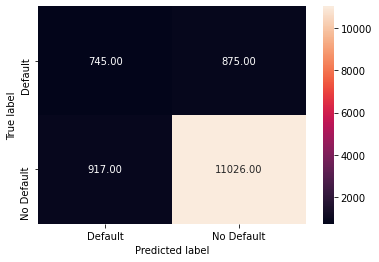

```python
draw_cm(y_test, test_pred)
```

```python
print( 'Total Accuracy : ',np.round( accuracy_score( y_test, test_pred ), 2 ) )
print('Precision : ' , np.round(precision_score( y_test, test_pred), 2 ))
print('Recall : ', np.round(recall_score( y_test, test_pred), 2))
print('R^2 score : ',np.round(r2_score( y_test, test_pred), 2) )
print("F1 score: ", np.round(f1_score( y_test, test_pred), 2))
```

```
Total Accuracy :  0.87
Precision :  0.45
Recall :  0.46
R^2 score :  -0.26
F1 score:  0.45
```

### Random Forest

```python
from sklearn.ensemble import RandomForestClassifier
rfcl = RandomForestClassifier(criterion = 'gini', max_depth = 20, min_samples_leaf=5)
rfcl = rfcl.fit(X_train, y_train)
test_pred_rm = rfcl.predict(X_test)
rfcl.score(X_test , y_test)
```

```
0.896040698960407
```

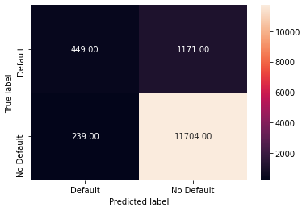

```python
draw_cm( y_test, test_pred_rm )
```

```python
print( 'Total Accuracy : ',np.round( accuracy_score( y_test, test_pred_rm ), 2 ) )
print('Precision : ' , np.round(precision_score( y_test, test_pred_rm), 2 ))
print('Recall : ', np.round(recall_score( y_test, test_pred_rm), 2))
print('R^2 score : ',np.round(r2_score( y_test, test_pred_rm), 2) )
print("F1 score: ", np.round(f1_score( y_test, test_pred_rm), 2))
```

```
Total Accuracy :  0.9
Precision :  0.65
Recall :  0.28
R^2 score :  0.01
F1 score:  0.39
```

### AdaBoost

```python
from sklearn.ensemble import AdaBoostClassifier
#abcl = AdaBoostClassifier(base_estimator=dt_model, n_estimators=50)
abcl = AdaBoostClassifier( n_estimators= 20)
abcl = abcl.fit(train_set, train_labels)

test_pred_ada = abcl.predict(test_set)
abcl.score(test_set , test_labels)
```

[output not shown]

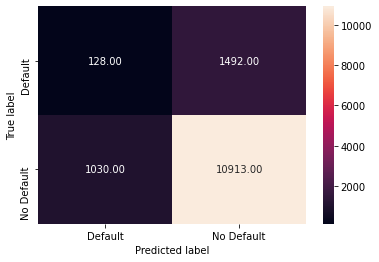

```python
draw_cm( y_test, test_pred_ada )
```

```python
print( 'Total Accuracy : ',np.round( accuracy_score( y_test, test_pred_ada ), 2 ) )
print('Precision : ' , np.round(precision_score( y_test, test_pred_ada), 2 ))
print('Recall : ', np.round(recall_score( y_test, test_pred_ada), 2))
print('R^2 score : ',np.round(r2_score( y_test, test_pred_ada), 2) )
print("F1 score: ", np.round(f1_score( y_test, test_pred_ada), 2))
```

```
Total Accuracy :  0.81
Precision :  0.11
Recall :  0.08
R^2 score :  -0.77
F1 score:  0.09
```

### Bagging

```python
from sklearn.ensemble import BaggingClassifier

bgcl = BaggingClassifier(n_estimators=10, max_samples= .7, bootstrap=True)
bgcl = bgcl.fit(X_train, y_train)

test_pred_bag = bgcl.predict(X_test)
bgcl.score(X_test , y_test)
```

```
0.8953771289537713
```

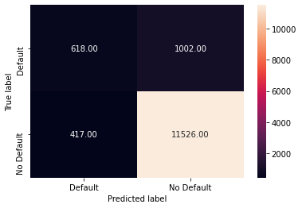

```python
draw_cm( y_test, test_pred_bag )
```

```python
print( 'Total Accuracy : ',np.round( accuracy_score( y_test, test_pred_bag ), 2 ) )
print('Precision : ' , np.round(precision_score( y_test, test_pred_bag), 2 ))
print('Recall : ', np.round(recall_score( y_test, test_pred_bag), 2))
print('R^2 score : ',np.round(r2_score( y_test, test_pred_bag), 2) )
print("F1 score: ", np.round(f1_score( y_test, test_pred_bag), 2))
```

```
Total Accuracy :  0.9
Precision :  0.6
Recall :  0.38
R^2 score :  0.01
F1 score:  0.47
```

### Gradient Boosting

```python
from sklearn.ensemble import GradientBoostingClassifier
gbcl = GradientBoostingClassifier(n_estimators = 50, learning_rate = 0.05)
gbcl = gbcl.fit(X_train, y_train)

test_pred_gb = gbcl.predict(X_test)
gbcl.score(X_test , y_test)
```

```
0.8876354788763547
```

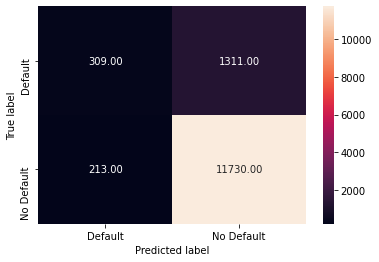

```python
draw_cm( y_test, test_pred_gb )
```

```python
print( 'Total Accuracy : ',np.round( accuracy_score( y_test, test_pred_gb ), 2 ) )
print('Precision : ' , np.round(precision_score( y_test, test_pred_gb), 2 ))
print('Recall : ', np.round(recall_score( y_test, test_pred_gb), 2))
print('R^2 score : ',np.round(r2_score( y_test, test_pred_gb), 2) )
print("F1 score: ", np.round(f1_score( y_test, test_pred_gb), 2))
```

```
Total Accuracy :  0.89
Precision :  0.59
Recall :  0.19
R^2 score :  -0.07
F1 score:  0.29
```

### 3.

Make a DataFrame to compare models and their metrics. Give conclusion regarding the best algorithm and your reason behind it.

```python
metrics_df = pd.DataFrame(np.array([["Gradient Boost", np.round( accuracy_score( y_test, test_pred_gb ), 2 ), np.round(precision_score( y_test, test_pred_gb), 2 ), np.round(recall_score( y_test, test_pred_gb), 2),np.round(r2_score( y_test, test_pred_gb), 2),np.round(f1_score( y_test, test_pred_gb), 2)  ],
                                    ["Decision Tree", np.round( accuracy_score( y_test, test_pred ), 2 ), np.round(precision_score( y_test, test_pred), 2 ), np.round(recall_score( y_test, test_pred), 2),np.round(r2_score( y_test, test_pred), 2),np.round(f1_score( y_test, test_pred), 2) ],
                                    ["Random Forest", np.round( accuracy_score( y_test, test_pred_rm ), 2 ), np.round(precision_score( y_test, test_pred_rm), 2 ), np.round(recall_score( y_test, test_pred_rm), 2),np.round(r2_score( y_test, test_pred_rm), 2),np.round(f1_score( y_test, test_pred_rm), 2) ],
                                    ["ADA", np.round( accuracy_score( y_test, test_pred_ada ), 2 ), np.round(precision_score( y_test, test_pred_ada), 2 ), np.round(recall_score( y_test, test_pred_ada), 2),np.round(r2_score( y_test, test_pred_ada), 2),np.round(f1_score( y_test, test_pred_ada), 2) ],
                                    ["Bagging", np.round( accuracy_score( y_test, test_pred_bag ), 2 ), np.round(precision_score( y_test, test_pred_bag), 2 ), np.round(recall_score( y_test, test_pred_bag), 2),np.round(r2_score( y_test, test_pred_bag), 2),np.round(f1_score( y_test, test_pred_bag), 2) ]]),
                   columns=['model','accuracy', 'precision', 'recall', 'r2','f1'])
metrics_df.head()
```

|  | model | accuracy | precision | recall | r2 | f1 |
| --- | --- | --- | --- | --- | --- | --- |
| 0 | Gradient Boost | 0.89 | 0.59 | 0.19 | -0.07 | 0.29 |
| 1 | Decision Tree | 0.87 | 0.45 | 0.46 | -0.26 | 0.45 |
| 2 | Random Forest | 0.9 | 0.65 | 0.28 | 0.01 | 0.39 |
| 3 | ADA | 0.81 | 0.11 | 0.08 | -0.77 | 0.09 |
| 4 | Bagging | 0.9 | 0.6 | 0.38 | 0.01 | 0.47 |

I think according to the metrics above, the best model to choose would be Bagging. Our precision is pretty high (though I would be wary of this on a much larger dataset and I'd be concerned about this model's ability to predict values outside the range of known values). The F1 score is the highest, though still relatively low considering a '1' is ideal. In terms of preciison and recall, we have a good trade off here for Bagging compared to the other models. The R2 score is really low meaning it doesn't do a good job of explaining the variance of the data so this is concerning. It seems that the models are all kind of doing something similar where they over-predict to a certain outcome and then accept the loss of the few they got wrong.